# NHS Fund Tracker - Interactive Plot Example

Ontario Non-Profit Housing Association

2025-01-10

# Overview of NHS Fund Allocation: *projects completed, in progress, or have received funding commitments*

This data relates to 6 NHS programs targeted for supply and repairs, such as the Affordable Housing Fund, Rapid Housing Initiative and the Apartment Construction Loan Program.

Of this 20.5 billion dollars, 4.9 billion dollars are in the form of contribution (24%), and 15.6 billion dollars are in the form of loans (76%).

**Note:** I will investigate why other provinces received disproportionately low amounts of funds, or if it is a data reporting problem.

**Program abbreviations:**

- Affordable Housing Fund = AHF
- Rapid Housing Initiative = RHI
- Apartment Construction Loan Program = ACLP
- Affordable Housing Innovation Fund = AHIF
- Federal Lands Initiative = FLI
- Federal Lands Disposition = FLD

[interactive chart not shown]

Note: this plot is interactive. Look at the icons on the top right of each plot to enable different interactive actions, such as scrolling in or zooming. Hover over the bars to see more details about the funding amounts and programs.

This funding amount has been used to support 231,729 *new and existing* units across Canada. 181,613 of these units are considered *affordable* by CMHC’s standards, and 50,116 units are not.

146,818 of these units are repairs and renewals, and 84,911 are new construction. A significant portion of funded units are related to repairing affordable units in Ontario (98,767 units).

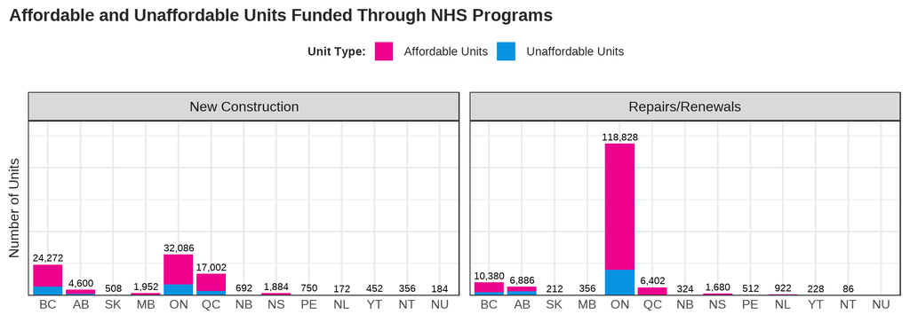

# A Focused Look at Ontario

Ontario has 32,086 units funded for new construction:

- 14,073 through the Apartment Construction Loan Program
- 10,211 through the Affordable Housing Fund
- 5,740 through the Affordable Housing Innovation Fund
- 1,777 through the Rapid Housing Initiative
- 285 through Federal Lands Disposition

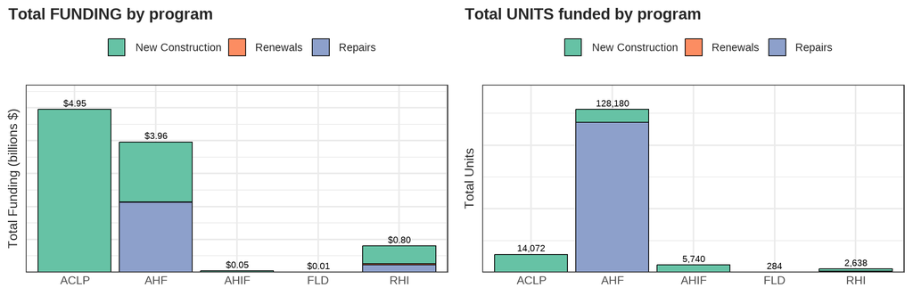

Looking specifically at affordable units, the vast majority of units are repairs through funds received by municipalities (92,477 units).

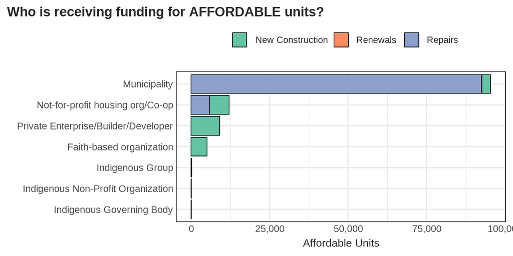

Going a level deeper and looking specifically at construction of affordable housing units, private developers are the most common proponent of projects, receiving funds predominately through the ACLP.

The Affordable Housing Fund goes primarily to non-profit and co-op organizations, creating 5,007 new units.

*Note:* I wonder if faith-based recipients receiving Affordable Housing Innovation Funds are primarily doing site conversions. I can find these proponent organizations as they may be of interest to us.

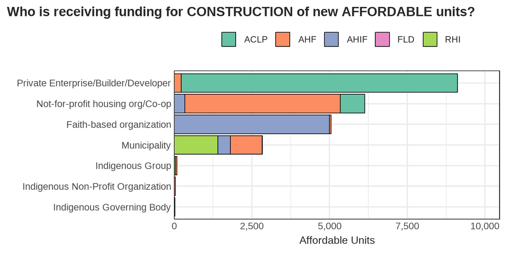

## Who receives what proportion of funding in Ontario?

Community housing organizations receive approximately 23.4% of all funding through the NHS, and presumably receive a significant amount more indirectly that flow through municipalities and other government recipients.

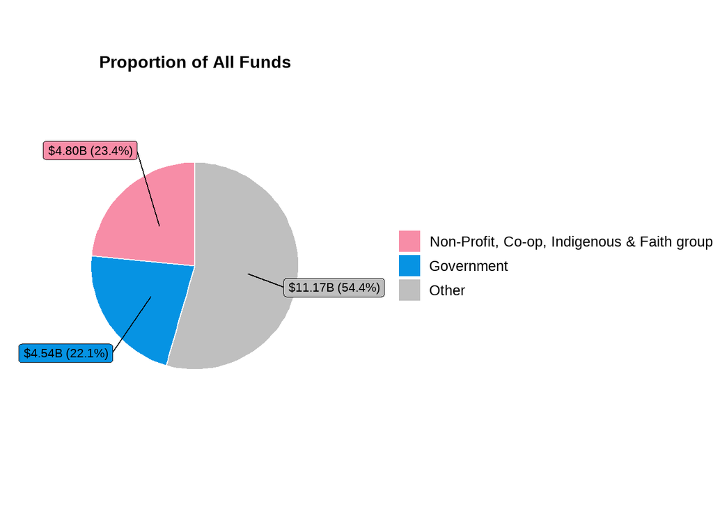

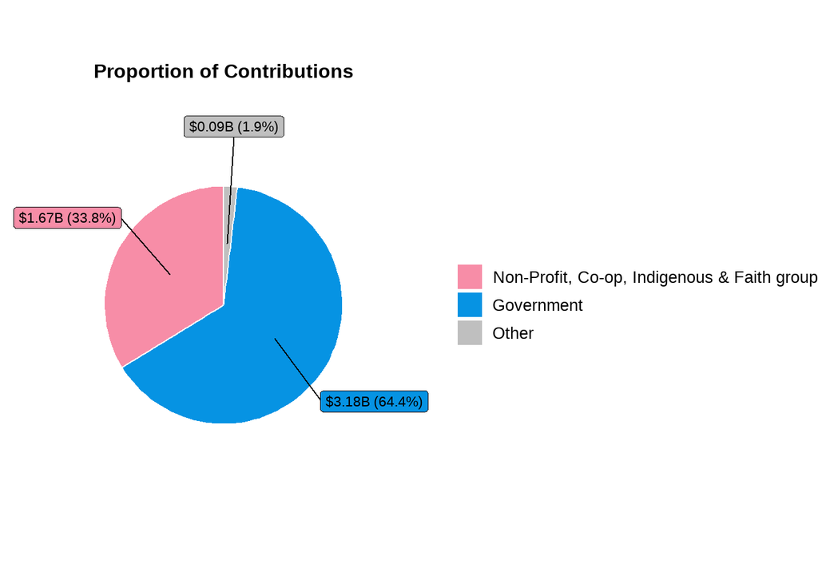